# Homogenindependence

Callum Feher

4/15/15

### Problem 1

Ho = Is that the personality types between gender are the same

Ha = Is that the personality types between gender are different

First define the chi function.

```r
chisq<-function(Obs)
{
  Exp <- outer(rowSums(Obs),colSums(Obs))/sum(Obs)
  sum((Obs-Exp)^2/Exp)
}
```

Load the data set.

```r
STT3850 <- read.csv(file=url("http://www1.appstate.edu/~thomleyje/R-datafiles/PersonalitySTT3850.csv"))
```

Select the two variables we want to test and make a table.Then use the function to calculate the chi-square test statistic (obs.diff)

```r
Observed <- table(STT3850$Gender,STT3850$Type)
Observed
```

```
##
##          ENFJ ENFP ENTJ ENTP ESFJ ESFP ESTJ ESTP INFJ INFP INTJ INTP ISFJ
##   Female    1    1    2    0    3    2    0    0    4    0    8    0    2
##   Male     11    1   12    5    3    1    2    2    5    4   35    6    1
##
##          ISFP ISTJ ISTP
##   Female    3    5    0
##   Male      5   11    4
```

```r
obs.diff <- chisq(Observed)
```

Permutation sampling simulation, start by selecting the two variables that are being analysed then run the simulation.

```r
set.seed(0)
Sex    <- subset(STT3850, select=Gender, drop=T)
Type <- subset(STT3850, select=Type,drop=T)

N <- 10^4-1
random.diff<-numeric(N)
for (i in 1:N)
{
  TYPE.perm <-sample(Type)
  RANDOM.table <- table(Sex, TYPE.perm)
  random.diff[i]<-chisq(RANDOM.table)
}
```

Graphing the results of the simulation and viewing the expected values table.

```r
Expected <- outer(rowSums(Observed),colSums(Observed))/sum(Observed)
Expected
```

```
##            ENFJ      ENFP      ENTJ     ENTP     ESFJ      ESFP      ESTJ
## Female 2.676259 0.4460432  3.122302 1.115108 1.338129 0.6690647 0.4460432
## Male   9.323741 1.5539568 10.877698 3.884892 4.661871 2.3309353 1.5539568
##             ESTP     INFJ      INFP      INTJ     INTP      ISFJ     ISFP
## Female 0.4460432 2.007194 0.8920863  9.589928 1.338129 0.6690647 1.784173
## Male   1.5539568 6.992806 3.1079137 33.410072 4.661871 2.3309353 6.215827
##             ISTJ      ISTP
## Female  3.568345 0.8920863
## Male   12.431655 3.1079137
```

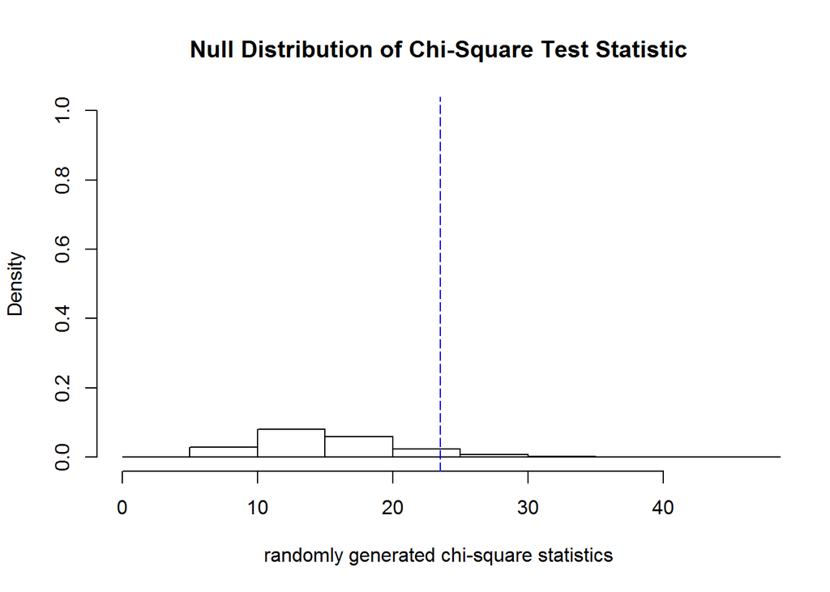

```r
hist(random.diff, prob=T,
     main="Null Distribution of Chi-Square Test Statistic",
     xlab="randomly generated chi-square statistics",
     xlim=c(0,max(max(random.diff),obs.diff)),
     ylim=c(0,1))
abline(v=obs.diff,
       col="blue",
       lty=5)
```

last but not least the p value

```r
print(paste("The chi-square test statistic is ", round(obs.diff,4), ".", sep=""),quote=F)
```

```
## [1] The chi-square test statistic is 23.5205.
```

```r
print(paste("The p-value for the test of independence is ", format((sum(random.diff >= obs.diff) + 1)/(N + 1),scientific=F), ".", sep=""),quote=F)
```

```
## [1] The p-value for the test of independence is 0.0682.
```

Rejecting the Ho is the as the p-value of the data is less than significance value of 0.10. Meaning the personality type is different by gender for the data set STT3850.

Some personality types had a majority of one gender in them.

### Problem 2

The other variable in the data set that could have an influence on the differences in personality type by gender is possible the major each of the students are in.

### Problem 3

```r
chisq.test(table(STT3850$Gender,STT3850$Type),correct=F)
```

```
##
##  Pearson's Chi-squared test
##
## data:  table(STT3850$Gender, STT3850$Type)
## X-squared = 23.5205, df = 15, p-value = 0.0737
```